# Analyzing Algal Growth and Herbivore Interactions in Intertidal Zones: two way ANOVA

Pascal Bärtschi

2023-08-20

This document explores the interaction between herbivores and height in relation to algal cover. We will analyze a dataset to uncover potential patterns and relationships using various data analysis techniques.

### Prerequisites and Data Loading

Importing the necessary libraries and loading the data set.

```r
suppressPackageStartupMessages({
  # Importing libraries
  library("ggplot2")
  library("dplyr")
  library("ggfortify")
  library('tidyverse')
  library('GGally')
})


# data
data <- read.csv("data/intertidalalgae.csv", stringsAsFactors = T)
```

### Data Exploration

We’ll begin by getting an overview of the dataset using the glimpse() and summary() functions. Additionally, we’ll examine the levels of the “herbivores” variable.

```r
glimpse(data)
```

```
## Rows: 64
## Columns: 3
## $ height     <fct> low, low, low, low, low, low, low, low, low, low, low, low,~
## $ herbivores <fct> minus, minus, minus, minus, minus, minus, minus, minus, min~
## $ Area_cm2   <dbl> 88.4648, 1188.0248, 2178.4142, 276.9608, 594.2624, 1470.768~
```

```r
summary(data)
```

```
##  height   herbivores    Area_cm2
##  low:32   minus:32   Min.   :   0.50
##  mid:32   plus :32   1st Qu.:  35.25
##                      Median : 495.69
##                      Mean   : 810.47
##                      3rd Qu.:1386.14
##                      Max.   :3732.72
```

```r
table(data$herbivores)
```

```
##
## minus  plus
##    32    32
```

```r
levels(data$herbivores)
```

```
## [1] "minus" "plus"
```

### Group Summary

```r
summary_data <- data %>%
  group_by(height, herbivores) %>%
  summarise()
summary_data
```

```
## # A tibble: 4 x 2
## # Groups:   height [2]
##   height herbivores
##   <fct>  <fct>
## 1 low    minus
## 2 low    plus
## 3 mid    minus
## 4 mid    plus
```

### Distribution of Algal Area

Let’s visualize the distribution of algal area using a histogram, grouped by “height” and “herbivores”.

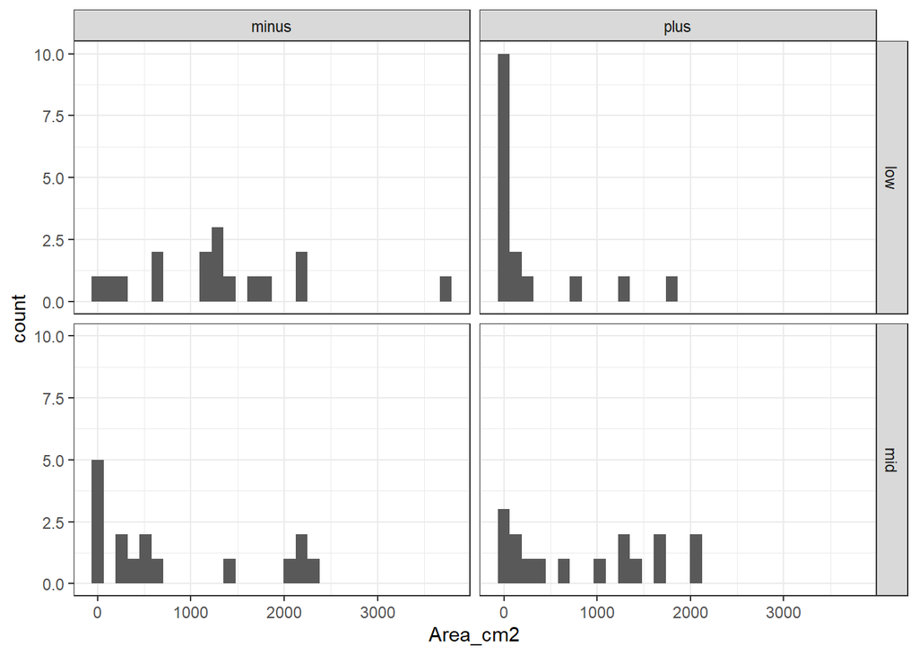

```r
ggplot(data, aes(x = Area_cm2)) +
  geom_histogram() +
  facet_grid(~height ~ herbivores) +
  theme_bw()
```

### Interaction Visualization

First, we’ll transform the area variable using the square root and update the dataset.

```r
data <- mutate(data, Area_root = sqrt(Area_cm2))
```

And second, we’ll create scatter plots to visualize the interaction between “herbivores” and “height” with respect to the transformed algal area.

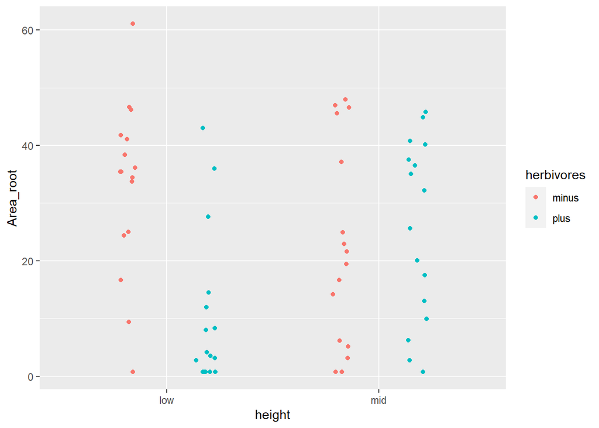

```r
ggplot(data, aes(x = height, y = Area_root, color = herbivores)) +
  geom_point(position = position_jitterdodge(jitter.width = 0.2))
```

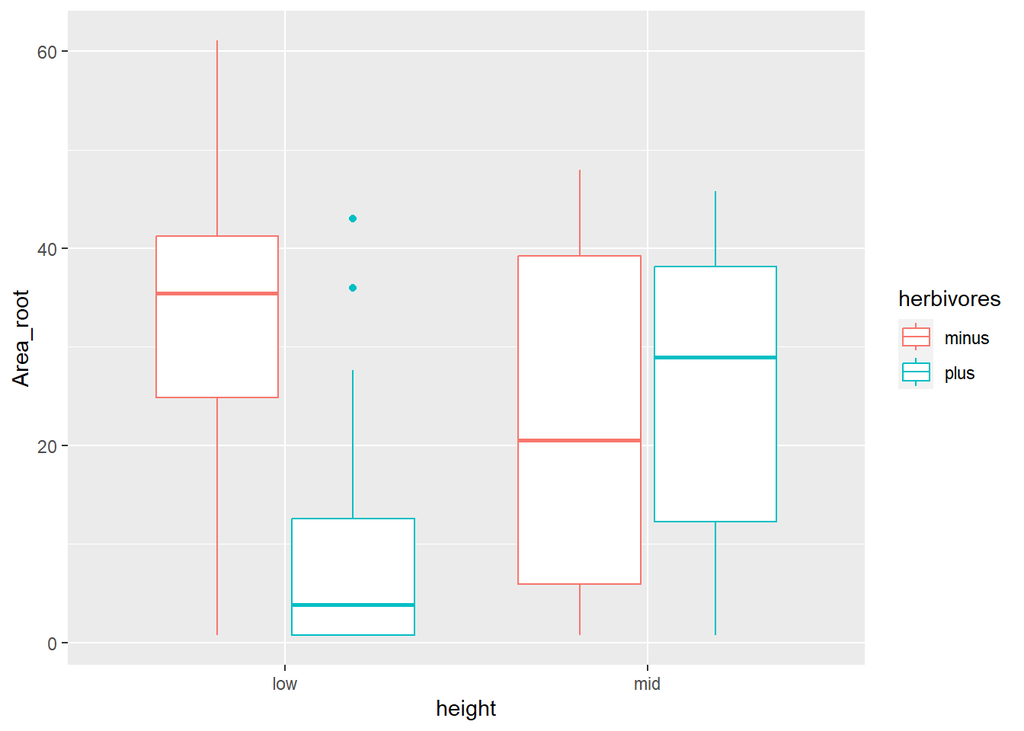

```r
ggplot(data, aes(x = height, y = Area_root, color = herbivores)) +
  geom_boxplot()
```

### Summary Statistics of Algal Cover

Compute the summary statistics of algal cover and standard errors.

```r
summary_algae <- data %>%
  group_by(height, herbivores) %>%
  summarise(mean = mean(Area_root), sd = sd(Area_root), se = sd(Area_root) / sqrt(n()))
options(pillar.sigfig = 4)
summary_algae
```

```
## # A tibble: 4 x 5
## # Groups:   height [2]
##   height herbivores  mean    sd    se
##   <fct>  <fct>      <dbl> <dbl> <dbl>
## 1 low    minus      32.91 14.95 3.736
## 2 low    plus       10.40 13.44 3.360
## 3 mid    minus      22.48 17.47 4.369
## 4 mid    plus       25.55 15.56 3.889
```

### Interaction Modeling

We will use linear regression to model the interaction between “herbivores” and “height” on the algal cover.

```r
model_algae <- lm(Area_root ~ herbivores * height, data = data)
```

The `autoplot()` function serves to check skewedness of the data or correlations between fitted values and residuals.

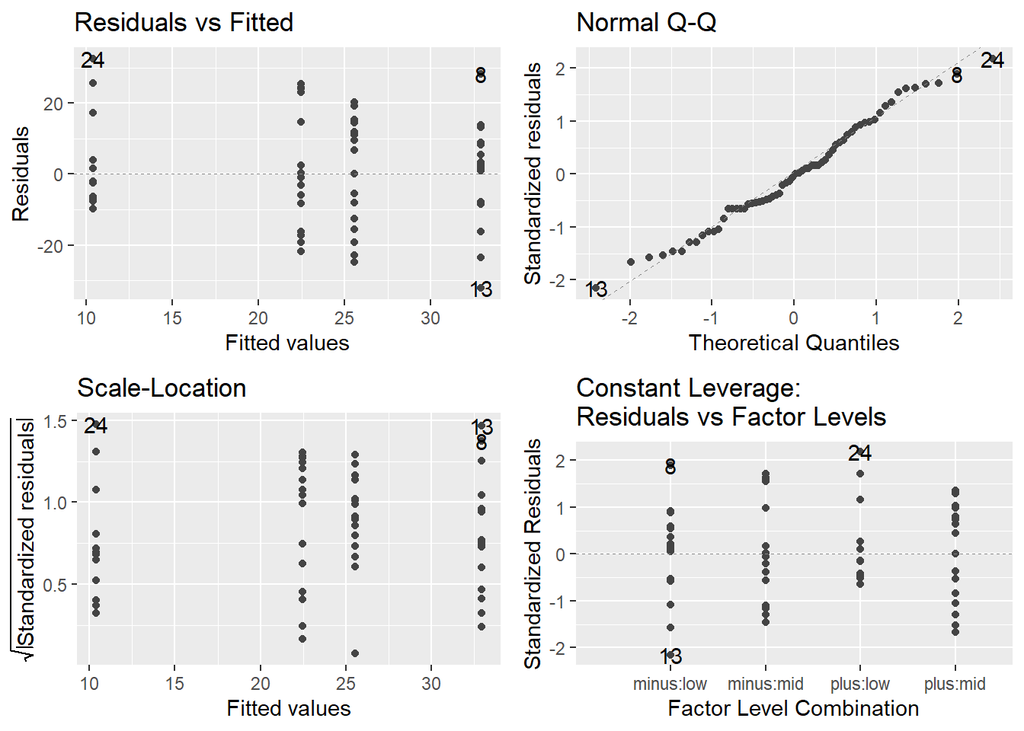

```r
autoplot(model_algae, smooth.colour = NA)
```

### ANOVA and Model Summary

We perform ANOVA and summarize the model.

```r
anova(model_algae)
```

```
## Analysis of Variance Table
##
## Response: Area_root
##                   Df  Sum Sq Mean Sq F value   Pr(>F)
## herbivores         1  1512.2 1512.18  6.3579 0.014360 *
## height             1    89.0   88.97  0.3741 0.543096
## herbivores:height  1  2617.0 2616.96 11.0029 0.001549 **
## Residuals         60 14270.5  237.84
## ---
## Signif. codes:  0 '***' 0.001 '**' 0.01 '*' 0.05 '.' 0.1 ' ' 1
```

```r
summary(model_algae)
```

```
##
## Call:
## lm(formula = Area_root ~ herbivores * height, data = data)
##
## Residuals:
##     Min      1Q  Median      3Q     Max
## -32.207  -9.697  -0.395  11.208  32.582
##
## Coefficients:
##                          Estimate Std. Error t value Pr(>|t|)
## (Intercept)                32.915      3.856   8.537 5.98e-12 ***
## herbivoresplus            -22.511      5.453  -4.128 0.000115 ***
## heightmid                 -10.431      5.453  -1.913 0.060519 .
## herbivoresplus:heightmid   25.578      7.711   3.317 0.001549 **
## ---
## Signif. codes:  0 '***' 0.001 '**' 0.01 '*' 0.05 '.' 0.1 ' ' 1
##
## Residual standard error: 15.42 on 60 degrees of freedom
## Multiple R-squared:  0.2281, Adjusted R-squared:  0.1896
## F-statistic: 5.912 on 3 and 60 DF,  p-value: 0.001329
```

### Confidence Intervals

We calculate confidence intervals for the model coefficients.

```r
conf_intervals <- confint(model_algae, level = 0.95)
conf_intervals
```

```
##                              2.5 %      97.5 %
## (Intercept)               25.20229  40.6267152
## herbivoresplus           -33.41746 -11.6040325
## heightmid                -21.33762   0.4758104
## herbivoresplus:heightmid  10.15367  41.0025187
```

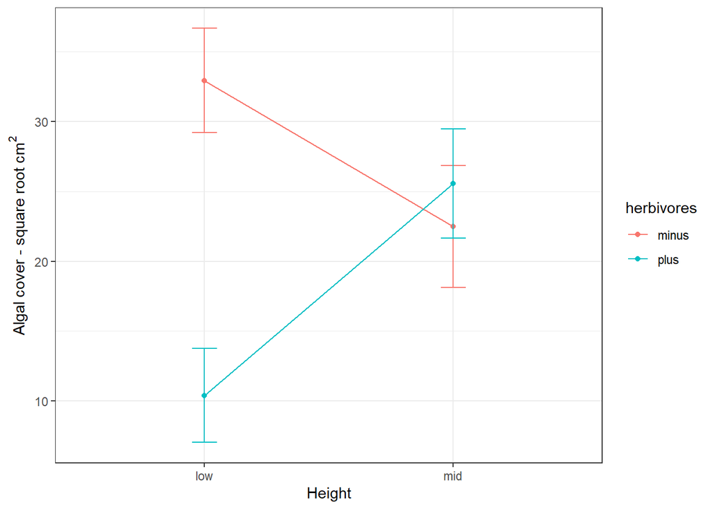

```r
ggplot(summary_algae, aes(x = height, y = mean,
                   color = herbivores, group = herbivores)) +
  geom_point() +
  geom_line() +
  geom_errorbar(aes(ymin = mean - se, ymax = mean + se), width = 0.1) +
  ylab(expression("Algal cover - square root cm"^"2")) +
  xlab('Height') +
  theme_bw()
```

### Conclusion

In this analysis, we explored the interaction between herbivores and height with regards to algal cover. The interaction plot and model results provide insights into the relationship between these variables.